# 02 - Data Visualisation 1

26 February, 2018

## overview

## Lesson Structure

An early look at data visualisation – see the power of R!

We'll look at:

- Reading data into R from external sources
- Understanding the ggplot syntax
- Plotting discrete and continuous data
- Changing basic visual features of plots

## Getting Started

First, we'll load the packages necessary for this class. We'll use the inbuilt `starwars` data set for the first half of this class.

```r
library(tidyverse)
```

This doesn't appear in your **Global Environment**, but it's there.

*Note*: This is one of many data sets built into the tidyverse package. R has a lot of these, useful for showing examples where your code doesn't work!

## The Star Wars Tibble

We know the data is a tibble, so we can just print the data name:

```r
# look at first 10 entries
starwars
```

```
## # A tibble: 87 x 13
##    name     height  mass hair_color skin_color eye_color birth_year gender
##    <chr>     <int> <dbl> <chr>      <chr>      <chr>          <dbl> <chr>
##  1 Luke Sk~    172  77.0 blond      fair       blue            19.0 male
##  2 C-3PO       167  75.0 <NA>       gold       yellow         112   <NA>
##  3 R2-D2        96  32.0 <NA>       white, bl~ red             33.0 <NA>
##  4 Darth V~    202 136   none       white      yellow          41.9 male
##  5 Leia Or~    150  49.0 brown      light      brown           19.0 female
##  6 Owen La~    178 120   brown, gr~ light      blue            52.0 male
##  7 Beru Wh~    165  75.0 brown      light      blue            47.0 female
##  8 R5-D4        97  32.0 <NA>       white, red red             NA   <NA>
##  9 Biggs D~    183  84.0 black      light      brown           24.0 male
## 10 Obi-Wan~    182  77.0 auburn, w~ fair       blue-gray       57.0 male
## # ... with 77 more rows, and 5 more variables: homeworld <chr>,
## #   species <chr>, films <list>, vehicles <list>, starships <list>
```

Anything else, and we should use `head()` to get an idea of the data!

## Plotting in ggplot2

### A Quick Plot

Let's plot the height and mass of the Star Wars characters, how does it look?

```r
ggplot(data = starwars) +
  geom_point(mapping = aes(x = mass, y = height))
```

## Plotting in ggplot2

### A Quick Plot

```
## Warning: Removed 28 rows containing missing values (geom_point).
```

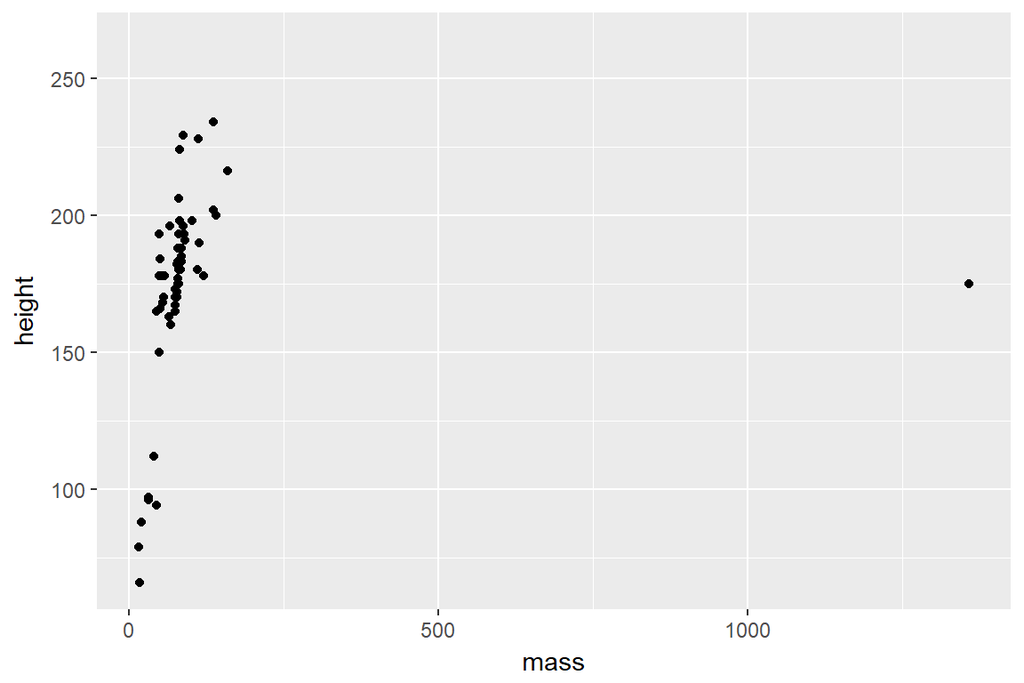

1. A warning about 28 rows that contain missing values
2. A really big outlier

## Plotting in ggplot2

### Understanding our Code

```r
ggplot(data = starwars) +
  geom_point(mapping = aes(x = mass, y = height))
```

- ggplot function call, always takes a data argument
- define our geom, e.g. `geom_point()`
- geom's map your data onto the plot by aethetics (how should it look)
- ggplot builts by layers

## Plotting in ggplot2

### Easy and Flexible

You can see how this makes ggplot so flexible:

1. **data**: pass different data sets to the same code
2. **aethetics**: different columns to your x and y axis
3. **aesthetics**: more than just what goes on the x and y axes

## Plotting in ggplot2

### Cleaning Before Plotting

R gave us a warning that we have rows containing missing values; here 28 people weren't plotted because they didn't have height and/or mass values.

We'll cover filtering data prior to plotting in lesson 4, but for now try this:

```r
filtered_starwars <- starwars %>%
  drop_na(height, mass)
```

## Adding Aesthetics

What's the relationship between mass and height within genders.

*Question*: How should we show gender? One option is colour.

```r
ggplot(data = filtered_starwars) +
  geom_point(mapping = aes(x = mass,
                           y = height,
                           colour = gender
                           )
             )
```

## Adding Aesthetics

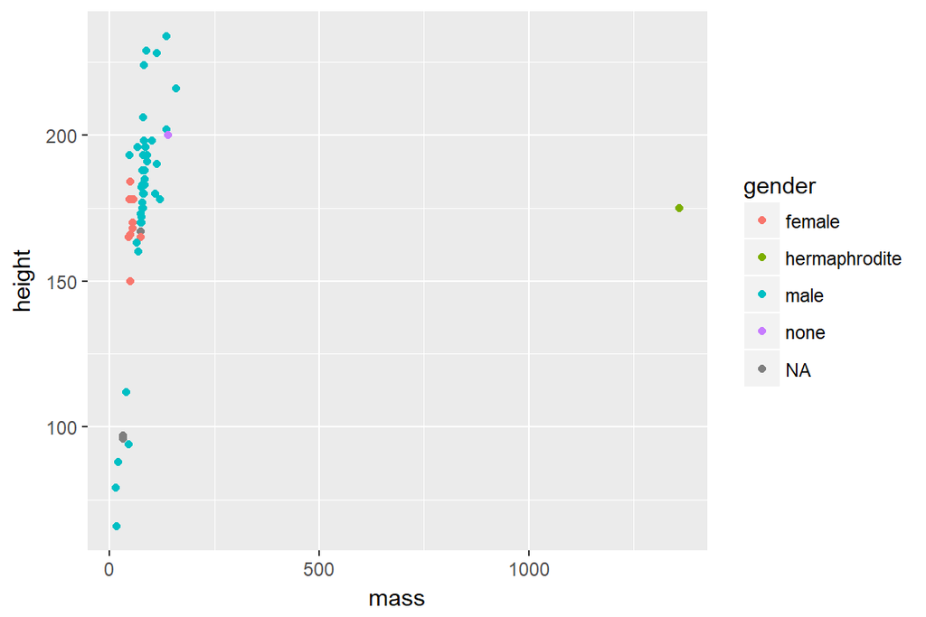

*Note*: No more warning: Why? We removed the NAs. Warnings just tell us R did something we mightn't have expected. Errors are when our code fails.

## Filtering within ggplot2

It's hard to see any relationsip between height and mass due to the outlier.

Two options:

- filter before we plot (lesson 4)
- restrict our axes in gglot2 (here)

```r
ggplot(data = filtered_starwars) +
  geom_point(mapping = aes(x = mass,
                           y = height,
                           colour = gender
                           )
             ) +
  coord_cartesian(xlim = c(0, 180))
```

## Filtering within ggplot2

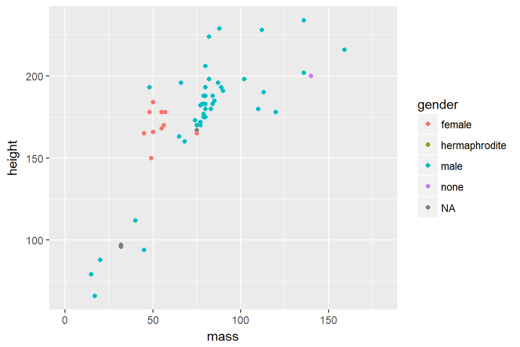

## Filtering within ggplot2

### How to Restrict our Data Range

- Added function `coord_cartesian()`
- Can take many arguments, but `xlim` sets the start and end value of your x-axis
- Other options do the same job, but throw out data prior to plotting

## Changing our Aethetics

Next up, we'll look at changing a few components of the points on the plot.

```r
ggplot(data = filtered_starwars) +
  geom_point(mapping = aes(x = mass,
                           y = height,
                           colour = gender
                           ),
             alpha = 0.7, # opacity
             shape = 17, # triangles
             size = 4) + # bigger points
  coord_cartesian(xlim = c(0, 180))
```

- Varying Looks = within the aethetic mapping
- Consistent Looks = outside the aethetic mapping

## Changing our Aethetics

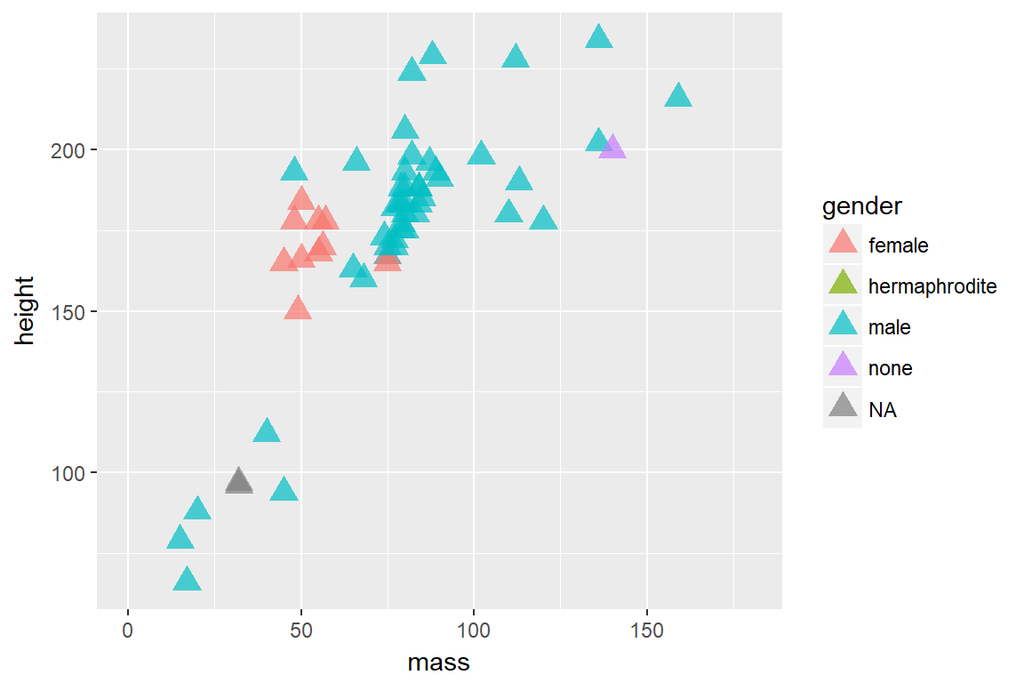

## Resolving Clashes

```r
ggplot(data = filtered_starwars) +
  geom_point(mapping = aes(x = mass,
                           y = height,
                           colour = gender
                           ),
             colour = "red") +
  coord_cartesian(xlim = c(0, 180))
```

## Resolving Clashes

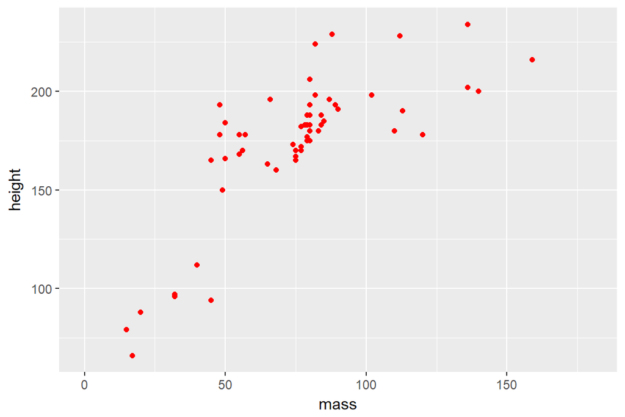

All points are same colour and we have no legend.

## Understanding the Values

R has some built in shapes that we can define within our plots. For shapes, these are divided into three categories:

- Colour border with hollow fill (0 - 14)
- Colourless border with colour fill (15 - 18)
- Colour border with colour fill (21 - 24)

Colour is a border, fill is solid colour.

## Understanding the Values

### Specific Colours

- Hex values or names for colours can specify what you want
- Try using the Hex selector at [htmlcolorcodes.com](http://htmlcolorcodes.com/)
- Define your colours with letters and numbers following a hash: `#af8dc3`

I use [colorbrewer2.org](http://colorbrewer2.org/#type=sequential&scheme=BuGn&n=3) for colourblind safe presentations for serious work.

## Understanding the Values

### A Demonstration

```r
ggplot(data = filtered_starwars, na.rm = T) +
  geom_point(mapping = aes(x = mass,
                           y = height,
                           colour = gender
                           ),
             colour = "#af8dc3",
             fill = "#7fbf7b",
             shape = 21,
             size = 8,
             stroke = 3
             ) +
  coord_cartesian(xlim = c(0, 180))
```

## Understanding the Values

### A Demonstration

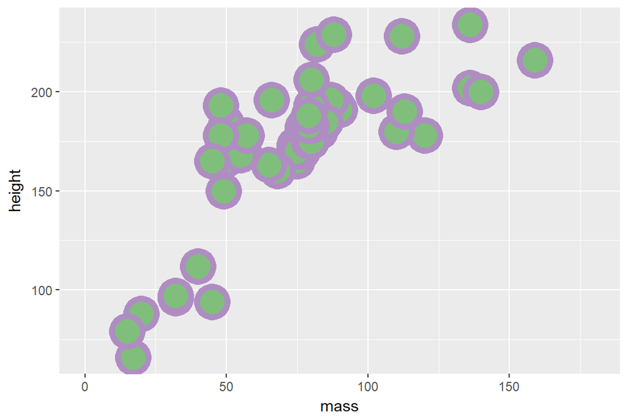

Play around with these values to see how they work.

## Continuous Colour

We've used the aesthetics above to define categorical data by colour. But what happens if we use continuous data?

```r
ggplot(data = filtered_starwars, na.rm = T) +
  geom_point(mapping = aes(x = mass,
                           y = height,
                           colour = birth_year
                           )
             ) +
  coord_cartesian(xlim = c(0, 180))
```

## Continuous Colour

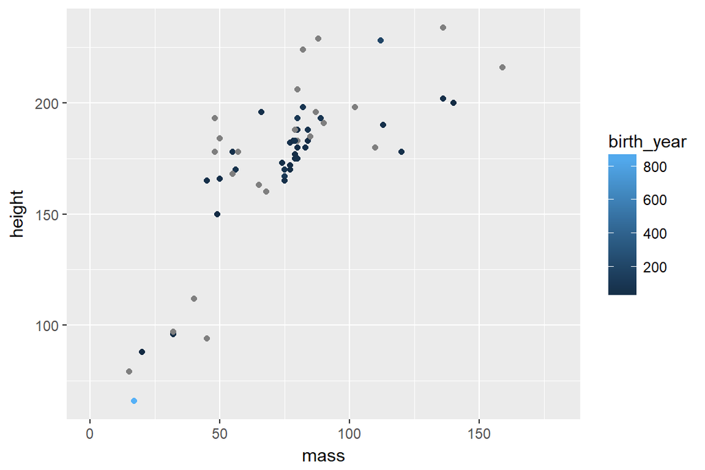

You can see that we get a sliding scale for the hue of the points. Pretty neat, but also quite difficult to get a real idea of where on the scale the points lie.

## Exploring Different Geoms

## Loading Data

Load the .csv file from the inputs folder. `read_csv()` is a quick way to load data as a tibble

```r
rt_data <- read_csv("inputs/rt_data.csv")
```

Look at the data:

```r
head(rt_data, n = 2)
```

```
## # A tibble: 2 x 4
##   particpant gender response_condition reaction_time
##        <int> <chr>  <chr>                      <dbl>
## 1          1 male   match                        340
## 2          2 female match                        350
```

Sentence reading task, turn a knob to see the next word. Does turning direction match direction of action in story?

## Bar Plots

- Very common
- Best for count data (less good for continuous, even if common)

How many participants from our recorded genders?

## Bar Plots

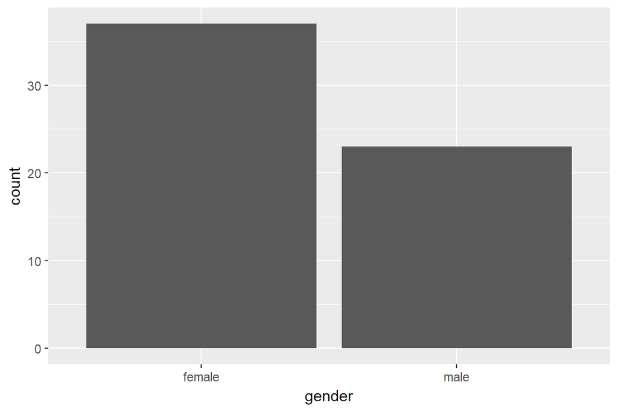

```r
ggplot(data = rt_data,
       mapping = aes(x = gender)
       ) +
  geom_bar()
```

## Box Plots

- Better for continuous outcomes (e.g. reaction time)
- Show more than just averages

```r
ggplot(data = rt_data,
       mapping = aes(x = response_condition,
                     y = reaction_time
                     )
       ) +
  geom_boxplot()
```

## Box Plots

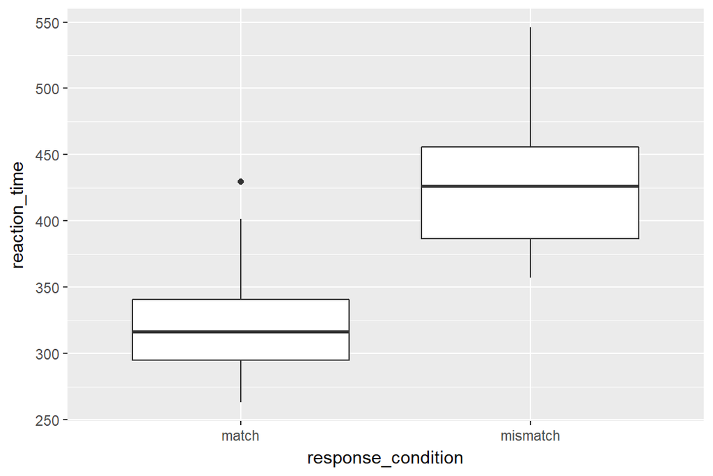

## How to Read a Box Plot

- Black line: median
- Box top/bottom: upper and lower quartiles (middle 50% of scores)
- Together the quartiles represent the interquartile range: The middle 50% of scores.
- Whiskers: most of the remainder
- Dots: outliers

## Violin Plots

- Like box plots, but shows the density of scores
- Need to ask for quantiles, and where
- To see full tails of the data, keep `trim` to `FALSE`

```r
ggplot(data = rt_data,
       mapping = aes(x = response_condition,
                     y = reaction_time
                     )
       ) +
  geom_violin(
    trim = FALSE,
    draw_quantiles = c(0.25, 0.5, 0.75)
    )
```

## Violin Plots

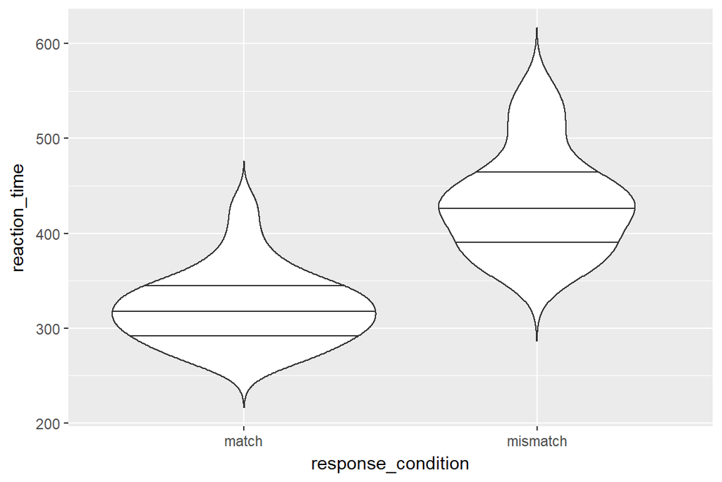

## Checking Distributions

## Density Plot

- Used for many observations

Only need 1 variable to plot (y-axis = density!)

```r
ggplot(data = rt_data,
       mapping = aes(x = reaction_time,
                     fill = response_condition
                     )
       ) +
  geom_density(alpha = 0.5) # alpha = opacity
```

Useful to change your alpha (transparency) to see overlapping distributions.

## Density Plot

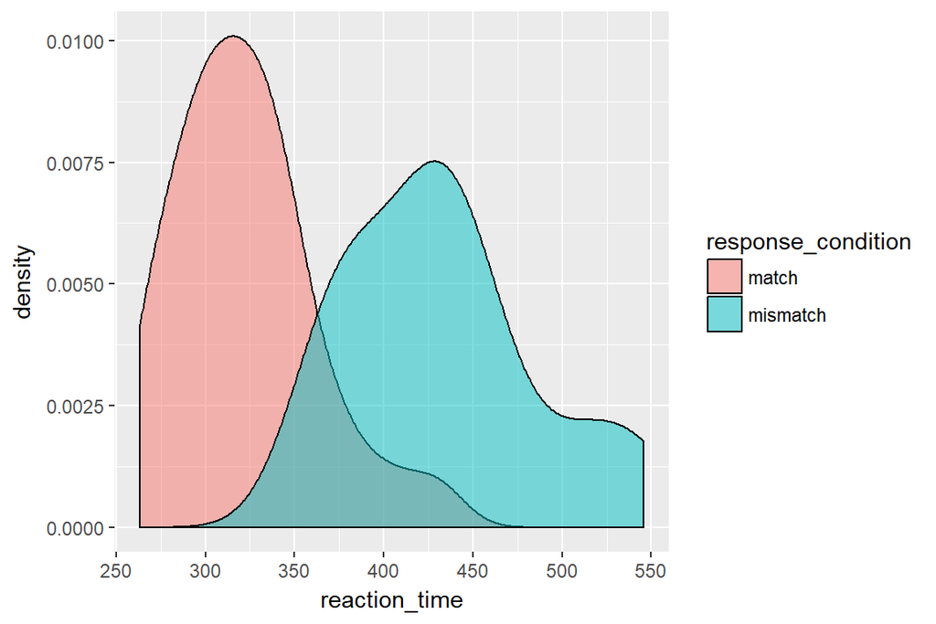

## Histograms

- Used for few observations (we'll use the same data though)

```r
ggplot(data = rt_data, mapping = aes(x = reaction_time)) +
  geom_histogram(binwidth = 50,
                 fill = "white",
                 colour = "black"
                 )
```

`Binwidth` argument tells R how to group your continuous data; how wide are the bars?

## Histograms

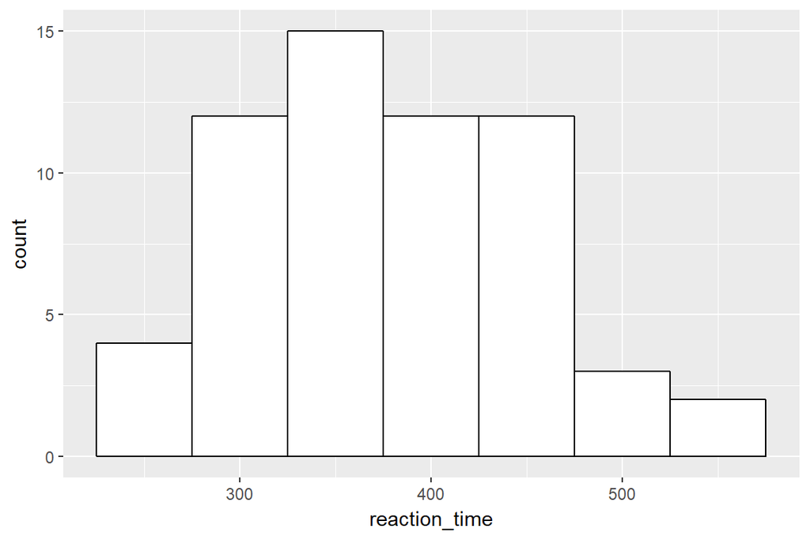